# J. Tellew - DBMI 2019 Blockchain Certificate Database R Notebook

# About

This is an [R Markdown](http://rmarkdown.rstudio.com) Notebook created to analyze some results of my project in the UCSD DBMI 2019 summer internship program.

# Plotting the Data

I’ll be making a plot (or several) over the next few sections using the data collected from experiments run on the AWS VM.

### Importing the Data

First, I’m going to import all of the `.csv` files in my data folder. Then, I’ll check my list of files to make sure that everything was found properly.

```r
# Get all of the .csv files in the directory and read them
data_filenames = list.files(path = "../results/test_add100_2019-08-13/", pattern="*.csv", full.names = T)
myfiles = lapply(data_filenames, function(x) read.csv(file = x, stringsAsFactors = FALSE))

# Make sure we read in the right files
head(data_filenames)
```

```
[1] "../results/test_add100_2019-08-13/test_add100_2019-08-13_14-49-20.csv"
[2] "../results/test_add100_2019-08-13/test_add100_2019-08-13_15-00-27.csv"
[3] "../results/test_add100_2019-08-13/test_add100_2019-08-13_15-11-55.csv"
[4] "../results/test_add100_2019-08-13/test_add100_2019-08-13_15-23-06.csv"
[5] "../results/test_add100_2019-08-13/test_add100_2019-08-13_15-33-36.csv"
[6] "../results/test_add100_2019-08-13/test_add100_2019-08-13_15-44-42.csv"
```

```r
# Make sure the files were read in properly
head(myfiles[[1]])
```

|  | certificates_added | time | memory | gas |
| --- | --- | --- | --- | --- |
| 1 | 0 | 00:00:00.000 | NA | NA |
| 2 | 1 | 00:00:01.553 | NA | NA |
| 3 | 2 | 00:00:03.961 | NA | NA |
| 4 | 3 | 00:00:06.56 | NA | NA |
| 5 | 4 | 00:00:07.936 | NA | NA |
| 6 | 5 | 00:00:09.422 | NA | NA |

### Cleaning the Data

The data is recorded in the format `hh:mm:ss.sss` which does not play nicely with R. I’ll be splitting the `time` column into three different numeric columns instead (`hours`, `minutes`, and `seconds`) to make it easier to plot.

```r
library(tidyr)
library(dplyr)

# Create a copy of the `myfiles` list
res = myfiles

# For each data frame in the list...
for(i in 1:length(res)) {

  # Split the time column into `hours`, `minutes`, and `seconds` columns
  data_i = myfiles[[i]]
  df_numeric_time = tidyr::separate(data = data_i, col = time, into = c("hours", "minutes", "seconds"), sep = ":" )

  # Convert the data from string to numeric
  df_numeric_time$hours = as.numeric(df_numeric_time$hours)
  df_numeric_time$minutes = as.numeric(df_numeric_time$minutes)
  df_numeric_time$seconds = as.numeric(df_numeric_time$seconds)

  # Add a column with the time represented in hours
  df_numeric_time$total_time_hours = (df_numeric_time$hours + (df_numeric_time$minutes / 60) + (df_numeric_time$seconds / 3600))

  # Add a column with the time represented in minutes
  df_numeric_time$total_time_minutes = ((df_numeric_time$hours * 60) + df_numeric_time$minutes + (df_numeric_time$seconds / 60))

  # Update the corresponding data frame in the copy list
  res[[i]] = df_numeric_time
}
```

### Creating the Plot

Now, I’ll go ahead and plot the data. My plot will be a line graph with each of the trials (each represented by a `.csv` file) plotted separately on the same graph.

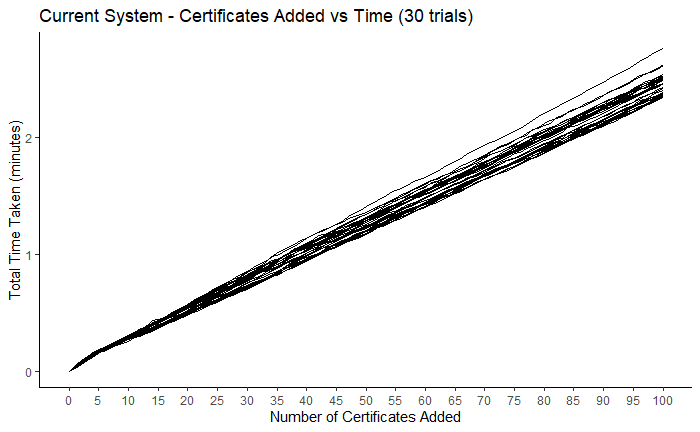

```r
library(ggplot2)
# Create the plot
combinedPlot = ggplot()

# Add a line to the plot for each data frame
for(i in 1:length(res)) {
  combinedPlot = combinedPlot + geom_line(data = res[[i]], aes(x = certificates_added, y = total_time_minutes, group=1))
}

# Set x-axis to every fifth element
combinedPlot = combinedPlot + scale_x_continuous(breaks = seq(0, 100, 5))

# Add title and change axis labels
combinedPlot = combinedPlot + ggtitle("Current System - Certificates Added vs Time (30 trials)") + xlab("Number of Certificates Added") + ylab("Total Time Taken (minutes)")

# Remove the default plot background and grid
combinedPlot_smallText = combinedPlot + theme_bw() + theme(panel.border = element_blank(), panel.grid.major = element_blank(), panel.grid.minor = element_blank(), axis.line = element_line(colour = "black"))

# Render the plot
combinedPlot_smallText

# Save the plot
combinedPlot_largeText = combinedPlot + theme_bw(base_size = 24) + theme(panel.border = element_blank(), panel.grid.major = element_blank(), panel.grid.minor = element_blank(), axis.line = element_line(colour = "black"))
ggsave(plot = combinedPlot_largeText, filename = "combinedPlot.png", units = "in", width = 16, height = 9, dpi = 240)
```

### Adding a Mean Line

Now, I’ll add a line to represent the mean so we can reduce clutter on the graph. The mean will be calculated by adding the values at each certificate interval together across all of the data frames, then dividing by the number of trials.

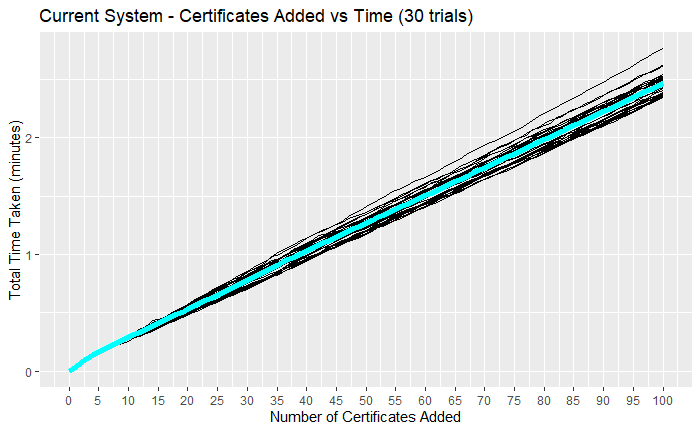

```r
# Create a vector from the total_time_minutes column of the first data frame
mean_total_time_minutes = res[[1]]$total_time_minutes

# Add the total_time_minutes column from each data frame in res to the mean vector

# For each data frame
for(j in 2:length(res)) {
  # For each row in the total_time_minutes column
  for(k in 2:length(res[[j]]$total_time_minutes)) {

    # Add the value to the corresponding row in the mean vector
    mean_total_time_minutes[[k]] = mean_total_time_minutes[[k]] + res[[j]]$total_time_minutes[[k]]
  }
}

# Divide each value in the vector by the number of trials to get the mean
for(m in 2:length(mean_total_time_minutes)) {
  mean_total_time_minutes[[m]] = mean_total_time_minutes[[m]] / length(res)
}

# Add a line to the plot showing the mean
combinedPlot_mean_smallText = combinedPlot + geom_line(data = res[[1]], aes(x = certificates_added, y = mean_total_time_minutes, group = 1), size = 2, color = "cyan")

# Render the plot
combinedPlot_mean_smallText

# Save the plot with larger font size
combinedPlot_mean_largeText = combinedPlot + theme_bw(base_size = 24) + theme(panel.border = element_blank(), panel.grid.major = element_blank(),panel.grid.minor = element_blank(), axis.line = element_line(colour = "black")) + geom_line(data = res[[1]], aes(x = certificates_added, y = mean_total_time_minutes, group = 1), size = 3, color = "cyan")

ggsave(plot = combinedPlot_mean_largeText, filename = "combinedPlot_mean.png", units = "in", width = 16, height = 9, dpi = 240)
```

# Comparing Mean Lines

Now I’m going to make a plot comparing the mean times between experiments running the old system with PDFs, the new system with PDFs, and the new system without PDFs.

### Calculating the Mean for the Strawman Experiment With PDFs

```r
# *** LOAD THE DATA ***

# Get all of the .csv files in the directory and read them
data_filenames_strawman = list.files(path = "../results/test_add100_2019-08-05/", pattern="*.csv", full.names = T)
myfiles_strawman = lapply(data_filenames_strawman, function(x) read.csv(file = x, stringsAsFactors = FALSE))

# *** CLEAN THE DATA ***

library(tidyr)
library(dplyr)

# Create a copy of the `myfiles` list
res_strawman = myfiles_strawman

# For each data frame in the list...
for(i in 1:length(res_strawman)) {

  # Split the time column into `hours`, `minutes`, and `seconds` columns
  data_i_strawman = myfiles_strawman[[i]]
  df_numeric_time = tidyr::separate(data = data_i_strawman, col = time, into = c("hours", "minutes", "seconds"), sep = ":" )

  # Convert the data from string to numeric
  df_numeric_time$hours = as.numeric(df_numeric_time$hours)
  df_numeric_time$minutes = as.numeric(df_numeric_time$minutes)
  df_numeric_time$seconds = as.numeric(df_numeric_time$seconds)

  # Add a column with the time represented in hours
  df_numeric_time$total_time_hours = (df_numeric_time$hours + (df_numeric_time$minutes / 60) + (df_numeric_time$seconds / 3600))

  # Add a column with the time represented in minutes
  df_numeric_time$total_time_minutes = ((df_numeric_time$hours * 60) + df_numeric_time$minutes + (df_numeric_time$seconds / 60))

  # Update the corresponding data frame in the copy list
  res_strawman[[i]] = df_numeric_time
}

# *** CALCULATE THE MEAN ***

# Create a vector from the total_time_minutes column of the first data frame
mean_total_time_minutes_strawman = res_strawman[[1]]$total_time_minutes

# Add the total_time_minutes column from each data frame in res to the mean vector

# For each data frame
for(j in 2:length(res_strawman)) {
  # For each row in the total_time_minutes column
  for(k in 2:length(res_strawman[[j]]$total_time_minutes)) {

    # Add the value to the corresponding row in the mean vector
    mean_total_time_minutes_strawman[[k]] = mean_total_time_minutes_strawman[[k]] + res_strawman[[j]]$total_time_minutes[[k]]
  }
}

# Divide each value in the vector by the number of trials to get the mean
for(m in 2:length(mean_total_time_minutes_strawman)) {
  mean_total_time_minutes_strawman[[m]] = mean_total_time_minutes_strawman[[m]] / length(res_strawman)
}
```

### Calculating the Mean for the Strawman Experiment Without PDFs

```r
# *** LOAD THE DATA ***

# Get all of the .csv files in the directory and read them
data_filenames_strawman_no_pdf = list.files(path = "../results/test_add100_2019-08-12_no-pdf/", pattern="*.csv", full.names = T)
myfiles_strawman_no_pdf = lapply(data_filenames_strawman_no_pdf, function(x) read.csv(file = x, stringsAsFactors = FALSE))

# *** CLEAN THE DATA ***

library(tidyr)
library(dplyr)

# Create a copy of the `myfiles` list
res_no_pdf = myfiles_strawman_no_pdf

# For each data frame in the list...
for(i in 1:length(res_no_pdf)) {

  # Split the time column into `hours`, `minutes`, and `seconds` columns
  data_i_strawman_no_pdf = myfiles_strawman_no_pdf[[i]]
  df_numeric_time = tidyr::separate(data = data_i_strawman_no_pdf, col = time, into = c("hours", "minutes", "seconds"), sep = ":" )

  # Convert the data from string to numeric
  df_numeric_time$hours = as.numeric(df_numeric_time$hours)
  df_numeric_time$minutes = as.numeric(df_numeric_time$minutes)
  df_numeric_time$seconds = as.numeric(df_numeric_time$seconds)

  # Add a column with the time represented in hours
  df_numeric_time$total_time_hours = (df_numeric_time$hours + (df_numeric_time$minutes / 60) + (df_numeric_time$seconds / 3600))

  # Add a column with the time represented in minutes
  df_numeric_time$total_time_minutes = ((df_numeric_time$hours * 60) + df_numeric_time$minutes + (df_numeric_time$seconds / 60))

  # Update the corresponding data frame in the copy list
  res_no_pdf[[i]] = df_numeric_time
}

# *** CALCULATE THE MEAN ***

# Create a vector from the total_time_minutes column of the first data frame
mean_total_time_minutes_strawman_no_pdf = res_no_pdf[[1]]$total_time_minutes

# Add the total_time_minutes column from each data frame in res to the mean vector

# For each data frame
for(j in 2:length(res_no_pdf)) {
  # For each row in the total_time_minutes column
  for(k in 2:length(res_no_pdf[[j]]$total_time_minutes)) {

    # Add the value to the corresponding row in the mean vector
    mean_total_time_minutes_strawman_no_pdf[[k]] = mean_total_time_minutes_strawman_no_pdf[[k]] + res_no_pdf[[j]]$total_time_minutes[[k]]
  }
}

# Divide each value in the vector by the number of trials to get the mean
for(m in 2:length(mean_total_time_minutes_strawman_no_pdf)) {
  mean_total_time_minutes_strawman_no_pdf[[m]] = mean_total_time_minutes_strawman_no_pdf[[m]] / length(res_no_pdf)
}
```

### Calculating the Mean for the Current System Without PDFs

```r
# *** LOAD THE DATA ***

# Get all of the .csv files in the directory and read them
data_filenames_no_pdf = list.files(path = "../results/test_add100_2019-08-14_no-pdf/", pattern="*.csv", full.names = T)
myfiles_no_pdf = lapply(data_filenames_no_pdf, function(x) read.csv(file = x, stringsAsFactors = FALSE))

# *** CLEAN THE DATA ***

library(tidyr)
library(dplyr)

# Create a copy of the `myfiles` list
res_no_pdf = myfiles_no_pdf

# For each data frame in the list...
for(i in 1:length(res_no_pdf)) {

  # Split the time column into `hours`, `minutes`, and `seconds` columns
  data_i_no_pdf = myfiles_no_pdf[[i]]
  df_numeric_time = tidyr::separate(data = data_i_no_pdf, col = time, into = c("hours", "minutes", "seconds"), sep = ":" )

  # Convert the data from string to numeric
  df_numeric_time$hours = as.numeric(df_numeric_time$hours)
  df_numeric_time$minutes = as.numeric(df_numeric_time$minutes)
  df_numeric_time$seconds = as.numeric(df_numeric_time$seconds)

  # Add a column with the time represented in hours
  df_numeric_time$total_time_hours = (df_numeric_time$hours + (df_numeric_time$minutes / 60) + (df_numeric_time$seconds / 3600))

  # Add a column with the time represented in minutes
  df_numeric_time$total_time_minutes = ((df_numeric_time$hours * 60) + df_numeric_time$minutes + (df_numeric_time$seconds / 60))

  # Update the corresponding data frame in the copy list
  res_no_pdf[[i]] = df_numeric_time
}

# *** CALCULATE THE MEAN ***

# Create a vector from the total_time_minutes column of the first data frame
mean_total_time_minutes_no_pdf = res_no_pdf[[1]]$total_time_minutes

# Add the total_time_minutes column from each data frame in res to the mean vector

# For each data frame
for(j in 2:length(res_no_pdf)) {
  # For each row in the total_time_minutes column
  for(k in 2:length(res_no_pdf[[j]]$total_time_minutes)) {

    # Add the value to the corresponding row in the mean vector
    mean_total_time_minutes_no_pdf[[k]] = mean_total_time_minutes_no_pdf[[k]] + res_no_pdf[[j]]$total_time_minutes[[k]]
  }
}

# Divide each value in the vector by the number of trials to get the mean
for(m in 2:length(mean_total_time_minutes_no_pdf)) {
  mean_total_time_minutes_no_pdf[[m]] = mean_total_time_minutes_no_pdf[[m]] / length(res_no_pdf)
}
```

### Creating a Data Frame

I’m going to create a data frame with the total certificates and the mean values from each of the three experiments so I can graph it with ggplot2

```r
df_means = data.frame(0:(length(mean_total_time_minutes) - 1), mean_total_time_minutes, mean_total_time_minutes_no_pdf, mean_total_time_minutes_strawman, mean_total_time_minutes_strawman_no_pdf)
colnames(df_means) = c("certificates_added", "mean_total_time_minutes", "mean_total_time_minutes_no_pdf", "mean_total_time_minutes_strawman", "mean_total_time_minutes_strawman_no_pdf")
head(df_means)
```

|  | certificates_added | mean_total_time_minutes | mean_total_time_minutes_no_pdf | mean_total_time_minutes_strawman | mean_total_time_minutes_strawman_no_pdf |
| --- | --- | --- | --- | --- | --- |
| 1 | 0 | 0.00000000 | 0.00000000 | 0.000000 | 0.0000000 |
| 2 | 1 | 0.03066111 | 0.02505444 | 2.871238 | 0.1157383 |
| 3 | 2 | 0.07425389 | 0.04484778 | 5.466101 | 0.2172756 |
| 4 | 3 | 0.10954111 | 0.06249167 | 8.179622 | 0.3095789 |
| 5 | 4 | 0.13730167 | 0.08420889 | 9.792973 | 0.3815339 |
| 6 | 5 | 0.16454944 | 0.10006722 | 11.300962 | 0.4653344 |

```r
tail(df_means)
```

|  | certificates_added | mean_total_time_minutes | mean_total_time_minutes_no_pdf | mean_total_time_minutes_strawman | mean_total_time_minutes_strawman_no_pdf |
| --- | --- | --- | --- | --- | --- |
| 96 | 95 | 2.340607 | 1.562687 | 271.5645 | 6.788142 |
| 97 | 96 | 2.367448 | 1.578515 | 276.2914 | 6.856212 |
| 98 | 97 | 2.391345 | 1.594351 | 280.6685 | 6.922809 |
| 99 | 98 | 2.414263 | 1.610140 | 284.9806 | 6.997842 |
| 100 | 99 | 2.438753 | 1.626763 | 289.5445 | 7.066154 |
| 101 | 100 | 2.464009 | 1.642786 | 294.4902 | 7.130311 |

### Plotting the Data Frame

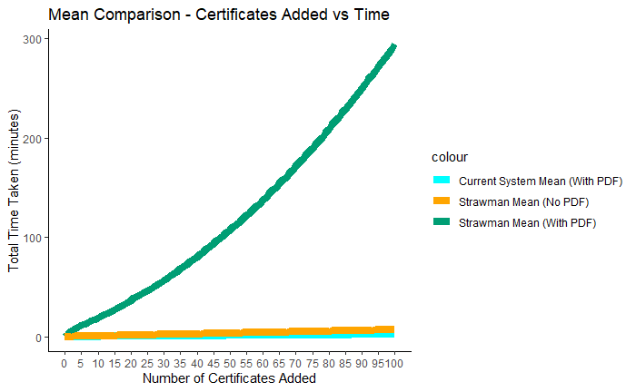

```r
library(ggplot2)

# Create the plot
meanPlot = ggplot()

# Set line thickness (currently optimized for the file saved version, not the notebook rendered version)
line_thickness = 3

# Add the mean line for the current system with PDFs
meanPlot = meanPlot + geom_line(data = df_means, aes(x = certificates_added, y = mean_total_time_minutes, group = 1, color = "Current System Mean (With PDF)"), size = line_thickness)

# Add the mean line for the current system without PDFs
# meanPlot = meanPlot + geom_line(data = df_means, aes(x = certificates_added, y = mean_total_time_minutes_no_pdf, group = 1, color = "Current System Mean (No PDF)"), size = line_thickness)

# Add the mean line for the strawman system with PDFs
meanPlot = meanPlot + geom_line(data = df_means, aes(x = certificates_added, y = mean_total_time_minutes_strawman, group = 1, color = "Strawman Mean (With PDF)"), size = line_thickness)

# Add the mean line for the strawman system without PDFs
meanPlot = meanPlot + geom_line(data = df_means, aes(x = certificates_added, y = mean_total_time_minutes_strawman_no_pdf, group = 1, color = "Strawman Mean (No PDF)"), size = line_thickness)

# Change line colors
meanPlot = meanPlot + scale_color_manual(values = c("Current System Mean (With PDF)" = "cyan", "Strawman Mean (With PDF)" = "#009e74", "Strawman Mean (No PDF)" = "orange"))

# Set x-axis to every fifth element
meanPlot = meanPlot + scale_x_continuous(breaks = seq(0, 100, 5))

# Add title and change axis labels
meanPlot = meanPlot + ggtitle("Mean Comparison - Certificates Added vs Time") + xlab("Number of Certificates Added") + ylab("Total Time Taken (minutes)")

# Remove the default plot background and grid
meanPlot_smallText = meanPlot + theme_bw() + theme(panel.border = element_blank(), panel.grid.major = element_blank(), panel.grid.minor = element_blank(), axis.line = element_line(colour = "black"))

# Render the plot
meanPlot_smallText

# Save the plot with larger font size
meanPlot_largeText = meanPlot + theme_bw(base_size = 24) + theme(panel.border = element_blank(), panel.grid.major = element_blank(),panel.grid.minor = element_blank(), axis.line = element_line(colour = "black"))

ggsave(plot = meanPlot_largeText, filename = "meanPlot.png", units = "in", width = 16, height = 9, dpi = 240)
```

### Plotting the Data Frame (Zoomed In)

```r
library(ggplot2)

# Create the plot
meanPlot_zoomed = ggplot()

# Set line thickness (currently optimized for the file saved version, not the notebook rendered version)
line_thickness = 3

# Add the mean line for the current system with PDFs
meanPlot_zoomed = meanPlot_zoomed + geom_line(data = df_means, aes(x = certificates_added, y = mean_total_time_minutes, group = 1, color = "Current System Mean (With PDF)"), size = line_thickness)

# Add the mean line for the current system without PDFs
meanPlot_zoomed = meanPlot_zoomed + geom_line(data = df_means, aes(x = certificates_added, y = mean_total_time_minutes_no_pdf, group = 1, color = "Current System Mean (No PDF)"), size = line_thickness)

# Add the mean line for the strawman system without PDFs
meanPlot_zoomed = meanPlot_zoomed + geom_line(data = df_means, aes(x = certificates_added, y = mean_total_time_minutes_strawman_no_pdf, group = 1, color = "Strawman Mean (No PDF)"), size = line_thickness)

# Change line colors
meanPlot_zoomed = meanPlot_zoomed + scale_color_manual(values = c("Current System Mean (With PDF)" = "cyan", "Current System Mean (No PDF)" = "pink", "Strawman Mean (No PDF)" = "orange"))

# Set x-axis to every fifth element
meanPlot_zoomed = meanPlot_zoomed + scale_x_continuous(breaks = seq(0, 100, 5))

# Add title and change axis labels
meanPlot_zoomed = meanPlot_zoomed + ggtitle("Mean Comparison - Certificates Added vs Time") + xlab("Number of Certificates Added") + ylab("Total Time Taken (minutes)")

# Remove the default plot background and grid
meanPlot_zoomed_smallText = meanPlot_zoomed + theme_bw() + theme(panel.border = element_blank(), panel.grid.major = element_blank(), panel.grid.minor = element_blank(), axis.line = element_line(colour = "black"))

# Render the plot
meanPlot_zoomed_smallText

# Save the plot
meanPlot_zoomed_largeText = meanPlot_zoomed + theme_bw(base_size = 24) + theme(panel.border = element_blank(), panel.grid.major = element_blank(), panel.grid.minor = element_blank(), axis.line = element_line(colour = "black"))
ggsave(plot = meanPlot_zoomed_largeText, filename = "meanPlot_zoomed.png", units = "in", width = 16, height = 9, dpi = 240)
```

[output not shown]

# Conclusion

I plotted several trials on the same graph and then found the mean. Then, I plotted the mean for 4 different experiments and compared them with two different graphs. I also showed some basic ggplot2 customizations for your graphs. Hopefully this has been a helpful explaination of how I created the graphs for this project. Thanks for reading!